# Health Insurance _ FinalProject

Harsh Bhatia

December 4, 2018

## Introduction

This dataset includes health insurance plan benefits and it’s details. I found this dataset on kaggle.*https://www.kaggle.com/hhs/health-insurance-marketplace* The data however was originally prepared and released by Center for Medicare and Medicaid Services (CMS)* https://www.cms.gov/cciio/resources/data-resources/marketplace-puf.html*

Through this research I planned on finding out how the Affordafle Care Act (ACA) has helped with the copay amounts for insurance.

```r
# reading the dataset
health <- read.csv("BenefitsCostSharing.csv")

dim(health)
```

```
## [1] 5048408      32
```

```r
str(health)
```

```
## 'data.frame':    5048408 obs. of  32 variables:
##  $ BenefitName        : Factor w/ 861 levels " Routine Exams and X-Rays - Child",..: 721 166 71 525 403 70 524 402 13 721 ...
##  $ BusinessYear       : int  2014 2014 2014 2014 2014 2014 2014 2014 2014 2014 ...
##  $ CoinsInnTier1      : Factor w/ 116 levels "","$0","0%","0% Coinsurance after deductible",..: 27 27 61 76 76 61 1 76 1 27 ...
##  $ CoinsInnTier2      : Factor w/ 38 levels "","$0","0%","0% Coinsurance after deductible",..: 1 1 1 1 1 1 1 1 1 1 ...
##  $ CoinsOutofNet      : Factor w/ 61 levels "","$0","0%","0% Coinsurance after deductible",..: 15 15 31 39 39 31 1 39 1 15 ...
##  $ CopayInnTier1      : Factor w/ 517 levels "","$0","$0 Copay after deductible",..: 515 515 515 515 515 515 1 515 1 515 ...
##  $ CopayInnTier2      : Factor w/ 279 levels "","$0","$0 Copay after deductible",..: 1 1 1 1 1 1 1 1 1 1 ...
##  $ CopayOutofNet      : Factor w/ 233 levels "","$0","$0 Copay after deductible",..: 231 231 231 231 231 231 1 231 1 231 ...
##  $ EHBVarReason       : Factor w/ 13 levels "","\nAdditional EHB Benefit",..: 5 11 11 7 11 5 1 5 1 5 ...
##  $ Exclusions         : Factor w/ 1721 levels ""," 6-month waiting period on Class II services for members age 19 and older, except for sealants and emergency pa"| __truncated__,..: 1 1 1 1 1 1 1 1 1 1 ...
##  $ Explanation        : Factor w/ 6228 levels "","- Only as medical necessity.  Not covered when related to weight reduction.",..: 1517 5343 5343 552 5343 1515 1 1514 1 1517 ...
##  $ ImportDate         : Factor w/ 266 levels "1/16/2015 17:32",..: 129 129 129 129 129 129 129 129 129 129 ...
##  $ IsCovered          : Factor w/ 4 levels "","Covered","Not covered",..: 2 2 2 2 2 2 1 2 1 2 ...
##  $ IsEHB              : Factor w/ 2 levels "","Yes": 1 2 2 1 2 1 1 1 1 1 ...
```

[output cut: 18 more lines]

The dataset is 1.23 GB in size and contains 32 variables with 5,048,408 observations.

## Data Cleaning

Out of the 32 variables present I will be selecting 4 variables that I think will be helpful for this project.

1. BenefitName: this the benefit covered by the insurance
2. BusinessYear: the year the entry into the database was recorded
3. CoinInnTier1: the copays associated with the insurance plan
4. StateCode: the abbreviated state code with the recorded entry

```r
# cleaning health based on the necessary 4 columns
names(health)
```

```
##  [1] "BenefitName"         "BusinessYear"        "CoinsInnTier1"
##  [4] "CoinsInnTier2"       "CoinsOutofNet"       "CopayInnTier1"
##  [7] "CopayInnTier2"       "CopayOutofNet"       "EHBVarReason"
## [10] "Exclusions"          "Explanation"         "ImportDate"
## [13] "IsCovered"           "IsEHB"               "IsExclFromInnMOOP"
## [16] "IsExclFromOonMOOP"   "IsStateMandate"      "IsSubjToDedTier1"
## [19] "IsSubjToDedTier2"    "IssuerId"            "IssuerId2"
## [22] "LimitQty"            "LimitUnit"           "MinimumStay"
## [25] "PlanId"              "QuantLimitOnSvc"     "RowNumber"
## [28] "SourceName"          "StandardComponentId" "StateCode"
## [31] "StateCode2"          "VersionNum"
```

```r
list <- c("BenefitName","BusinessYear","CoinsInnTier1","StateCode")
health_clean <- health %>%
  select(list)
dim(health_clean)
```

```
## [1] 5048408       4
```

I wanted to focus on ChemoTherapy for this project.

ChemoTherapy is the treatment of disease, especially cancer, using chemical substances. It is one of the most expensive medical treatments and requires a lot of attention and care while the patient is going through this process. There is use of multiple anti-cancer drugs involved, which makes it even more complex. The whole process of chemotherapy in itself is very long and comprises of various steps.

For someone without a proper medical insurance, chemotherapy can be real burden on the shoulders, if an unfortunate case of going through chemotherapy does walk past the life.

So we will do this project and try to find out what are the kind of copays are there for chemotherapy, in US and in New Jersey also.

```r
health_chemo <- health_clean %>%
  filter(BenefitName == "Chemotherapy") %>%
  group_by(BenefitName, BusinessYear, StateCode, CoinsInnTier1)

dim(health_chemo)
```

```
## [1] 65704     4
```

First I want to the change the CoinsInnTier1 from factor to numeric datatype.

This is very unorganized with % symbols, so we will first clean then change to numeric datatype.

```r
# Change the coins in tier from factor to numeric data type
head(health_chemo$CoinsInnTier1)
```

```
## [1] No Charge No Charge 15%       15%       0%        15%
## 116 Levels:  $0 0% 0% Coinsurance after deductible ... Not Applicable
```

```r
health_chemo$CoinsInnTier1 <- gsub(pattern = "%",replacement =  "", x = health_chemo$CoinsInnTier1)
head(health_chemo$CoinsInnTier1)
```

```
## [1] "No Charge" "No Charge" "15"        "15"        "0"         "15"
```

```r
health_chemo$CoinsInnTier1 <- as.numeric(health_chemo$CoinsInnTier1)
```

Upon changing to numeric field type we see that there were a lot of NA introduced. So I will set all NAs to 0

```r
# remove the field that have NAs
health_chemo$CoinsInnTier1[is.na(health_chemo$CoinsInnTier1)] <- 0

summary(health_chemo$CoinsInnTier1)
```

```
##    Min. 1st Qu.  Median    Mean 3rd Qu.    Max.
##  0.0000  0.0000  0.0000  0.6498  0.0000 50.0000
```

From the summary we can see that a lot of plans have either 0% copay or another fee associated with the Chemotherapy. So we will not consider these in our research.

```r
health_chemo <- subset(x = health_chemo, CoinsInnTier1 > 0)
summary(health_chemo$CoinsInnTier1)
```

```
##    Min. 1st Qu.  Median    Mean 3rd Qu.    Max.
##    5.00   10.00   20.00   21.77   30.00   50.00
```

```r
dim(health_chemo)
```

```
## [1] 1961    4
```

After cleaning the data, we now have 4 variables and 1961 observations.

## Graphs and other visuals

1. In the first graph, we have the copay percentage of insurers. We are trying to see what is the most common copay percentage in the US for chemotherapy.

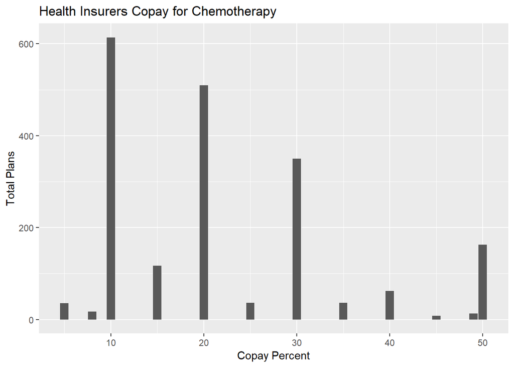

```r
ggplot(data = health_chemo) +
  geom_bar(mapping = aes(x = CoinsInnTier1),data = health_chemo) +
  labs(x = "Copay Percent", y = "Total Plans")+
  ggtitle("Health Insurers Copay for Chemotherapy")
```

We can see that most of the insurers, a little over 600, have about 10% of copay.

There are also a few insurers that have a copay of 50%, which is not a good sign.

2. In the 2nd graph, we move to NJ to find out the trend in insurance plan and the copay assoicated.

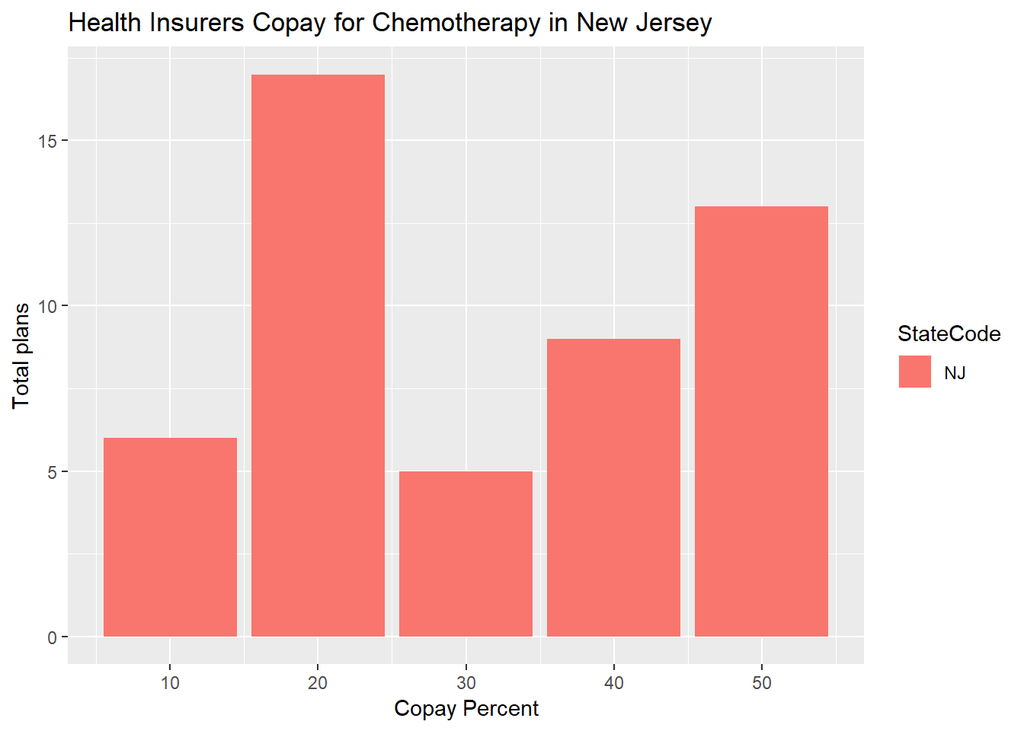

```r
health_chemo %>%
  filter(StateCode == "NJ") %>%
  ggplot() +
  geom_bar(aes(CoinsInnTier1, fill = StateCode), stat = "count") +
  labs(x = "Copay Percent", y = "Total plans") +
  ggtitle("Health Insurers Copay for Chemotherapy in New Jersey")
```

In New Jersey, we see that the common copay is 20%, unlike that in the whole country, where most the insurers have 10% copay.

We still see that NJ has some insurers that have a copay of 50%.

3. In the 3rd graph, I focused on knowing more about people paying 50% copay for chemotherapy.

My goal was to check the trend to see what was going on year wise since the ACA was launched.

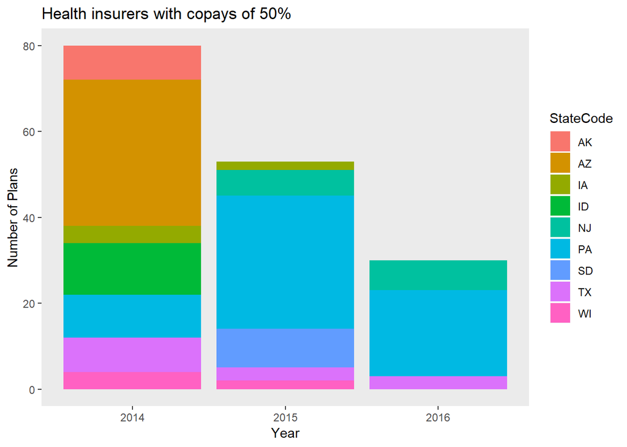

```r
health_chemo %>%
  filter(CoinsInnTier1 == "50") %>%
  ggplot() +
  geom_bar(mapping = aes(x = BusinessYear, fill = StateCode))+
  labs(x = "Year", y = "Number of Plans") +
  ggtitle("Health insurers with copays of 50%") +
  theme(panel.grid.major = element_blank(), panel.grid.minor = element_blank())
```

So there is a positive trend as the number of plans with copays of 50% seems to be coming down.

## Conclusion

Chemotherapy is a very expensive treatment and it is very necessary for the government to make sure that the people are given a proper and affordable coverage against chemotherapy. Through this project we have seen some trends that give us a positive indication of how the Affordable Care Act (ACA) has benefited copay rates.

It is worth noticing that Pennsylvania (PA) has the most insurance plans with copays of 50%. With our state, New Jersey (NJ), also having some plans in which the insurer has to pay 50% for chemotherapy.